# 统计计算 Homework-6 报告

林子开 21307110161

2023年11月

# Exercise 7.1

```r
rm(list=ls())
n = nrow(law) # 总的样本数量
y = law$LSAT
z = law$GPA
cor.hat = cor(y,z) # 由全部样本估计的相关系数
print(cor.hat)
```

```
## [1] 0.7763745
```

```r
# compute the jackknife replicates, leave-one-out estimates
cor.jack = numeric(n)
for(i in 1:n){
  cor.jack[i] = cor(y[-i],z[-i]) # 由n-1个样本估计得到的相关系数
}
bias <- (n-1) * (mean(cor.jack) - cor.hat)
se = sqrt((n-1) * mean((cor.jack-cor.hat)^2))
# bias
print(bias)
```

```
## [1] -0.006473623
```

```r
# standard error
print(se)
```

```
## [1] 0.1425291
```

# Exercise 7.4

首先，我们给出$\lambda$的MLE的推导过程。设$x_i\sim f(x)=\lambda\text{e}^{-\lambda x}$ 似然函数为：
$$\mathcal{L}(x_1,x_2,\cdots,x_n|\lambda) =
\prod_{i=1}^{n}\lambda\exp\{-\lambda x_i\}
= \lambda^n \exp\{-\lambda \sum_{i=1}^{n} x_i\}$$
对数似然函数
$$l(x_1,x_2,\cdots,x_n|\lambda) =
\log(\mathcal{L}(x_1,x_2,\cdots,x_n|\lambda)) = n\log\lambda - \lambda
\sum_{i=1}^{n} x_i$$
对上式求导，并令其等于零：
$$\frac{\partial l}{\partial \lambda} = \frac{n}{\lambda} -
\sum_{i=1}^{n}x_i = 0$$
得到$\lambda = \frac{n}{\sum_{i=1}^{n}x_i}$。 根据上述结论，定义下述计算$\lambda$的函数

```r
hazard_rate = function(x){
  lambda = length(x)/sum(x)
  return(lambda)
}
```

下面是利用bootstrap计算bias和se的过程

```r
data(aircondit,package = 'boot')
B = 200
n = nrow(aircondit)
lambda.hat = hazard_rate(aircondit) # 根据原始样本计算得到的lambda
print(lambda.hat)
```

```
## [1] 0.00077101
```

```r
# bootstrap estimate of lambda
lambda.bootstrap = numeric(B)
set.seed(2023)
for(b in 1:B){
  index = sample(1:n,size=n,replace = T) # 随机抽取样本的下标
  mySample = aircondit[index,1]
  lambda.bootstrap[b] = hazard_rate(mySample)
}

# bias
print(bias.lambda <- mean(lambda.bootstrap-lambda.hat))
```

```
## [1] 0.00983408
```

```r
# standard error
print(se.lambda <- sd(lambda.bootstrap))
```

```
## [1] 0.004232146
```

# Exercise 7.6

散点图和相关系数矩阵如下：

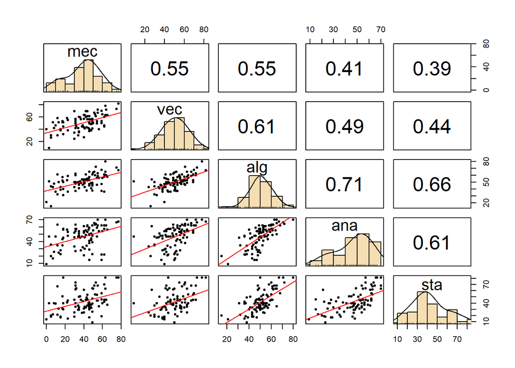

```r
rm(list=ls())
pairs.panels(scor,
             pch=20,
             method = "pearson", # correlation method
             hist.col = "wheat",
             density = TRUE,  # show density plots
             lm = T,
             ellipses = F # show correlation ellipses,
)
```

可以看出，相关系数的绝对值越接近1的变量，散点图越会集中分布在一条直线附近，线性相关性更明显。

以下是基于bootstrap对相关系数se的估计

```r
# bootstrap estimate of se
set.seed(2023)
se.bootstrap <- function(data){
  B = 200
  n = nrow(data)
  cor.bootstrap = numeric(B)
  for(b in 1:B){
    index = sample(1:n,size=n,replace = T)
    mySample = data[index,]
    cor.bootstrap[b] = cor(mySample[,1],mySample[,2])
  }
  return(sd(cor.bootstrap))
}

se.cor12 <- se.bootstrap(scor[,c(1,2)])
se.cor34 <- se.bootstrap(scor[,c(3,4)])
se.cor35 <- se.bootstrap(scor[,c(3,5)])
se.cor45 <- se.bootstrap(scor[,c(4,5)])
print(c(se.cor12,se.cor34,se.cor35,se.cor45))
```

```
## [1] 0.07206776 0.05163261 0.06604007 0.07207374
```

# Exercise 7.7 & 7.8

首先定义计算$\theta$的函数：

```r
rm(list=ls())
theta <- function(data){
  Sigma <- ((n-1)/n) * cov(data) # 协方差矩阵的MLE估计
  eigen.values = eigen(Sigma)$values # 特征值，降序排列
  return(eigen.values[1]/sum(eigen.values))
}
```

根据所有样本计算$\hat{\theta}$

```r
set.seed(2023)
B = 200
n = nrow(scor)
theta.hat = theta(scor) # 根据原始样本计算得到的theta.hat
print(theta.hat)
```

```
## [1] 0.619115
```

利用bootstrap估计bias和se

```r
# bootstrap
theta.bootstrap = numeric(B)
for(b in 1:B){
  index = sample(1:n,size=n,replace = T) # 随机抽取样本的下标
  mySample = scor[index,]
  theta.bootstrap[b] = theta(mySample)
}

# bias
print(bias.theta.bootstrap <- mean(theta.bootstrap-theta.hat))
```

```
## [1] 0.004833522
```

```r
# se
print(se.theta.bootstrap <- sd(theta.bootstrap))
```

```
## [1] 0.04664458
```

利用Jackknife估计bias和se

```r
# jackknife
# compute the jackknife replicates, leave-one-out estimates
theta.jack = numeric(n)
for(i in 1:n){
  theta.jack[i] = theta(scor[-i,])
}

# bias
bias.theta.jackknife <- (n-1) * (mean(theta.jack) - theta.hat)
print(bias.theta.jackknife)
```

```
## [1] 0.001069139
```

```r
# se
se.theta.jackknife = sqrt((n-1) * mean((theta.jack-theta.hat)^2))
print(se.theta.jackknife)
```

```
## [1] 0.04955244
```

# 证明题

## 有放回抽样时样本均值的标准差

由于
$$x_i \stackrel{iid}{\sim}F_N(X)$$
其中$F_N(X)$是$\{X_1,X_2,\cdots,X_N\}$上的均匀分布。那么有
$$\text{Var}(x_i) = \mathbb{E}[x_i-\mathbb{E}(x_i)] =
\frac{1}{N}\sum_{i=1}^{N}(X_i-\bar{X}) = S^2$$
由于$x_i$之间相互独立，则
$$\text{Var}(\bar{x}) = \text{Var}\left(\frac{\sum_{i=1}^{n}x_i}{n}\right)
= \frac{1}{n}\text{Var}(x_i) = \frac{1}{n}S^2$$
再由 standard deviation 和 variance 的关系，可以得到：
$$se(\bar{x}) = \sqrt{\text{Var}(\bar{x})} = \sqrt{\frac{1}{n}S^2} =
\frac{S}{\sqrt{n}}$$

## 无放回抽样时样本均值的标准差

当$n=1$时
$$se(\bar{x}) = se(x_1) = \sqrt{\text{Var}(x_1)} = S =
\frac{S}{\sqrt{1}}\left(\frac{N-1}{N-1}\right)^{(1/2)}$$
当$1<n<N$时,我们先证明如下引理：
$$\text{if}\; i\ne j,\, \mathbb{E}[x_ix_j] =
\frac{N}{N-1}\bar{X}^2-\frac{1}{N-1}\mathbb{E}[x_i^2]$$
证明：$x_i$可以等概率地从$\{X_1,X_2,\cdots,X_N\}$中进行选择，而$x_j$可以从$\{X_1,X_2,\cdots,X_N\}\setminus \{x_i\}$中等概率地进行选择。因此有
$$\begin{align*}
\mathbb{E}[x_ix_j] &= \frac{1}{N(N-1)}\left[ \sum_{i\ne j}X_iX_j
\right] \\
&= \frac{1}{N(N-1)}\left[ \sum_{i=1}^{N}\sum_{j=1}^{N}X_iX_j
-\sum_{i=1}^{N}X_i^2 \right] \\
&= \frac{1}{N(N-1)}\left[ N^2\bar{X}^2 -N\mathbb{E}[x_i^2] \right]
\\
&=\frac{N}{N-1}\bar{X}^2-\frac{1}{N-1}\mathbb{E}[x_i^2]
\end{align*}$$
引理得证。

进一步，我们有
$$\begin{align*}
\text{Var}(\bar{x}) & = \frac{1}{n^2}\text{Var}(\sum_{i=1}^{n}x_i)
\\
&= \frac{1}{n^2} \sum_{i,j}\text{Cov}(x_i,x_j)
\end{align*}$$

当$i=j$时
$$\text{Cov}(x_i,x_i) = \text{Var}(x_i) = \mathbb{E}[x_i^2] -
\left(\mathbb{E}[x_i]\right)^2 =
\mathbb{E}[x_i^2] - \bar{X}^2$$

当$i\ne j$时
$$\begin{align*}
\text{Cov}(x_i,x_j) &=
\mathbb{E}[x_ix_j]-\mathbb{E}[x_i]\mathbb{E}[x_j]\\
&= \frac{N}{N-1}\bar{X}^2-\frac{1}{N-1}\mathbb{E}[x_i^2] -
\mathbb{E}[x_i]\mathbb{E}[x_j] \\
&=\frac{N}{N-1}\bar{X}^2-\frac{1}{N-1}\mathbb{E}[x_i^2] - \bar{X}^2
\\
&=\frac{1}{N-1}\bar{X}^2 - \frac{1}{N-1}\mathbb{E}[x_i^2]
\end{align*}$$

因此有
$$\begin{align*}
\text{Var}(\bar{x}) &= \frac{1}{n^2} \sum_{i,j}\text{Cov}(x_i,x_j)\\
&= \frac{1}{n^2} \left[n \left(\mathbb{E}[x_i^2] -
\bar{X}^2\right)-n(n-1)\left(\frac{1}{N-1}\bar{X}^2 -
\frac{1}{N-1}\mathbb{E}[x_i^2]\right) \right] \\
&= \frac{1}{n}\mathbb{E}[x_i^2] - \frac{1}{n}\bar{X}^2 +
\frac{n-1}{n(N-1)}\bar{X}^2 - \frac{n-1}{n(N-1)}\mathbb{E}[x_i^2] \\
&= \frac{N-n}{n(N-1)}\left( \mathbb{E}[x_i^2] - \bar{X}^2 \right) \\
&= \frac{N-n}{n(N-1)} S^2
\end{align*}$$

最终得到
$$se(\bar{x}) = \sqrt{\text{Var}(\bar{x})} =
\frac{S}{\sqrt{n}}\left(\frac{N-n}{N-1}\right)^{1/2}$$

## 不相同的Bootstrap样本数量

记$y_k$是样本$(x_1,x_2,\cdots,x_N)$中取$X_k$的数量，满足$0\le y_k \le N$。 该问题等价于求方程
$$y_1 + y_2 +\cdots + y_N = N$$
的所有非负整数解的个数。

做变换$z_k = y_k + 1$，则原问题又等价于求方程
$$z_1 + z_2 + \cdots + z_N = 2N$$
所有正整数解的个数。这可以借助组合数学中的隔板模型进行求解：有$2N$个球，排成一排，形成$2N-1$个内部空隙，向这$2N-1$个内部空袭插入$N-1$个隔板，每个空袭最多插一个隔板，那么不同的插入隔板方式为
$${2N-1 \choose N-1} = \frac{(2N-1)!}{(N-1)!N!}$$
因此，bootstrap不同样本数量为$\frac{(2N-1)!}{(N-1)!N!}$

证毕